# Mestrado em Hemoterapia: Bioestatística

## Dispersão dos Dados

Considere dois conjuntos de dados:

\(A = \{10,20,30\}\), \(\overline{x}_A = 20\), \(s_A= 10\).

\(B = \{10000,10010,10020\}\), \(\overline{x}_B = 10010\), \(s_B= 10\).

Ambos têm o mesmo desvio padrão.

Se compararmos as escalas de cada conjunto de dados, poderíamos dizer que o segundo conjunto tem menor dispersão.

Por exemplo, a maior observação do conjunto \(B\), 10020, é 0.2% maior do que a menor observação, 10000.

A maior observação do conjunto \(A\), 30, é 3 vezes maior do que a menor observação, 10.

## Exemplo

Considere notas de 2 provas:

- Prova 1: 0 a 100. Média da turma: 70. Desvio padrão 1.
- Prova 2: 0 a 10. Média da turma: 7. Desvio padrão 1.

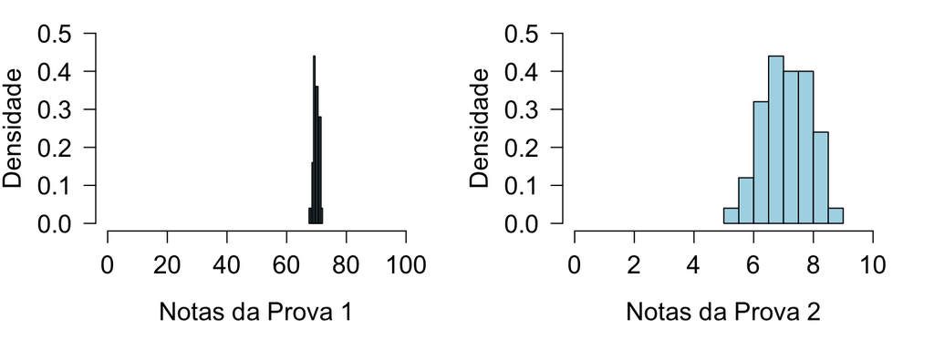

Neste caso, como as escalas são diferentes, não podemos tirar conclusões usando apenas o desvio padrão.

## Coeficiente de Variação

\[\mbox{Coeficiente de Variação (CV)}= \frac{s}{\bar{x}}\]

**Exemplo:** \(A = \{10, 20, 30\}\), \(\overline{x}_A = 20\), \(s_A= 10\).

\(B = \{10000, 10010, 10020\}\), \(\overline{x}_B = 10010\), \(s_B= 10\).

\(CV_A = \frac{s_A}{\overline{x}_A} = 0.5\) e \(CV_B = \frac{s_B}{\overline{x}_B} \approx 0.0009\).

**Exemplo:** Prova 1: 0 a 100. Média da turma: 70. Desvio padrão 1.

Prova 2: 0 a 10. Média da turma: 7. Desvio padrão 1.

\(CV_1 = \frac{s_1}{\overline{x}_1} = 0.014\) e \(CV_2 = \frac{s_2}{\overline{x}_2} \approx 0.14\).

## Usando medidas de posição para descrever dispersão

Média e mediana: medidas de posição **central**.

Amplitude e desvio padrão: medidas de dispersão.

Há outros tipos de medida de posição para descrever a distribuição dos dados: **quartis** e **percentis**.

**Quartis** dividem os dados em 4 partes iguais: primeiro quartil (\(Q_1\)), segundo quartil (\(Q_2\)) e o terceiro quartil (\(Q_3\)).

O **p-ésimo percentil** é o valor tal que uma porcentagem **p** dos dados ficam abaixo dele.

## Quartis

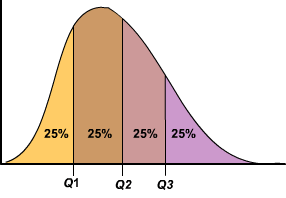

Para obter os quartis:

- Ordene os dados em ordem crescente.
- Encontre a mediana: \(Q_2\)=mediana.
- Considere o subconjunto de dados abaixo da mediana. \(Q_1\) é a mediana deste subconjunto de dados.
- Considere o subconjunto de dados acima da mediana. \(Q_3\) é a mediana deste subconjunto de dados.

## Exemplo: Quantidade de sódio (mg) em 20 cereais matinais

0, 70, 125, 125, 140, 150, 170, 170, 180, **200**

**200**, 210, 210, 220, 220, 230, 250, 260, 290, 290

Para calcular \(Q1\): calcula-se a mediana considerando apenas as 10 primeiras observações ordenadas: 0, 70, 125, 125, \(\underbrace{140, 150}_{Q_1=145}\), 170, 170, 180, **200**

Para calcular \(Q3\): calcula-se a mediana considerando apenas as 10 últimas observações ordenadas: **200**, 210, 210, 220, \(\underbrace{220, 230}_{Q_3=225}\), 250, 260, 290, 290

## Quartis e Assimetria

Os quartis também fornecem informação sobre o formato da distribuição.

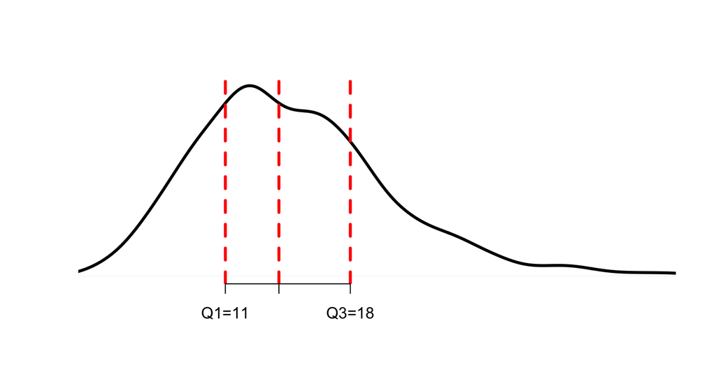

A mediana \(Q_2\) é 14. A distância entre \(Q_1\) e \(Q_2\) é 3, enquanto que a distância entre \(Q_2\) e \(Q_3\) é 4, indicando que a distribuição é assimétrica à direita.

## Usando quartis para medir dispersão

A vantagem do uso de quartis sobre o desvio padrão ou a amplitude, é que os quartis são mais resistentes a dados extremos.

**Intervalo interquartílico (IQ)** = \(Q_3-Q_1\).

Representa 50% dos dados localizados na parte central da distribuição.

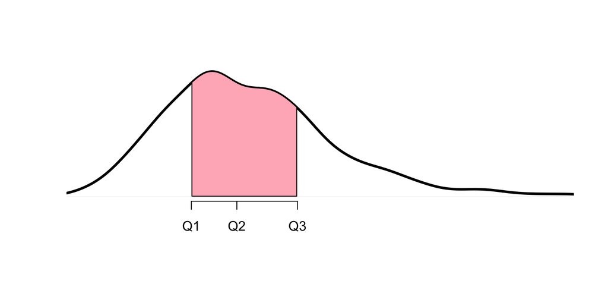

## Esquema dos 5 números

## Esquema dos 5 números

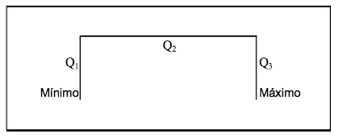

Notação: \(x_{(1)}\) = mínimo, \(x_{(n)}\) = máximo, onde \(x_{(k)}\) é a \(k\)-ésima observação depois de ordenar os dados.

\[ Q_2= \begin{cases} x_{\left(\frac{n+1}{2}\right)} \,,& \mbox{se $n$ é ímpar} \\ \frac{x_{\left(\frac{n}{2}\right)}+x_{\left(\frac{n}{2}+1\right)}}{2}\,, & \mbox{se $n$ é par} \end{cases} \]

## Quartis e simetria da distribuição

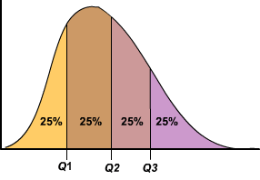

Para uma distribuição simétrica ou aproximadamente simétrica:

- \(Q_2-x_{(1)}\approx x_{(n)}-Q_2\)
- \(Q_2-Q_1\approx Q_3-Q_2\)
- \(Q_1-x_{(1)} \approx x_{(n)}-Q_3\)
- distâncias entre a mediana e \(Q_1\), \(Q_3\) menores do que as distâncias entre os extremos e \(Q_1\), \(Q_3\).

## Dados discrepantes (*outliers*)

Importante: examinar os dados para verificar se há observações discrepantes.

- Média e desvio padrão são muito afetados por observações discrepantes.
- Após detectar a observação discrepante, verificar se não é um erro de digitação ou um caso especial da sua amostra.
- Com poucos dados, podemos detectar um dados discrepante facilmente, apenas observando a sequência ordenada.
- Podemos usar o IQ como um critério mais geral de detecção de dados discrepantes.

## Dados discrepantes (*outliers*)

Uma observação é um potencial *outlier* se está abaixo de \(Q_1-1.5\times IQ\) ou se está acima de \(Q_3+1.5 \times IQ\).

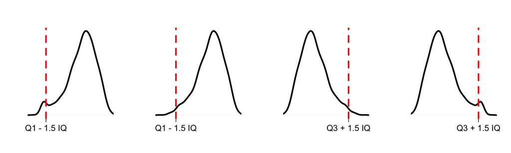

Dizemos *potencial outlier*, pois se a distribuição tem cauda longa (à direita ou à esquerda), algumas observações irão cair no critério, apesar de não serem outliers.

## Boxplot

O esquema dos 5 números forma a base do gráfico denominado **boxplot**.

**Primeiro passo:** construir uma caixa que vai do primeiro ao terceiro quartil.

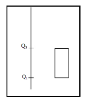

## Boxplot

**Segundo passo:** construir uma linha no meio da caixa, na altura da mediana (\(Q_2\)).

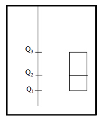

## Boxplot

**Terceiro passo:** definir os limites para que uma observação seja considerada *outlier*.

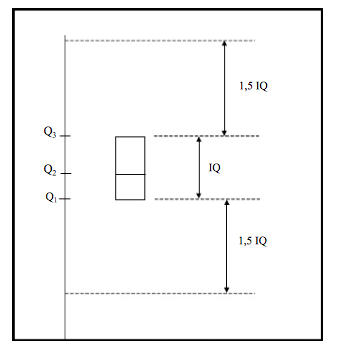

## Boxplot

**Quarto passo:** desenhar uma linha que saia da parte inferior da caixa e desça até o menor valor dos dados, mas que não ultrapasse os limites do critério de outliers. Desenhar uma linha que saia da parte superior da caixa e suba até o maior valor dos dados, mas que não ultrapasse os limites do critério de outliers. Outliers, quando existem, aparecem indicados separadamente no gráfico.

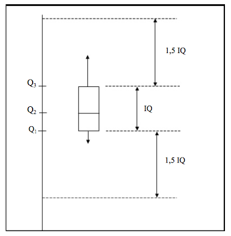

## Exemplo: População, em 1000 habitantes, dos estados brasileiros

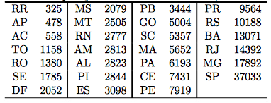

27 estados, \(n\) é ímpar, mediana é \(x_{\left(\frac{n+1}{2}\right)}= x_{\left(\frac{27+1}{2}\right)}=x_{(14)}=3098\) (ES).

A metade inferior dos dados: 13 observações. A mediana deste subconjunto é \(Q_1=x_{(7)}= 2052\) (DF).

A metade superior dos dados: 13 observações. A mediana deste subconjunto é \(Q_3=x_{(21)}=7919\) (PE).

## Exemplo: População dos estados brasileiros

\(IQ=Q_3-Q_1=7919-2052=5867\)

\(Q_1-1.5\times IQ=-6748.5\)

\(Q_3+1.5\times IQ=16720\)

Temos outliers?

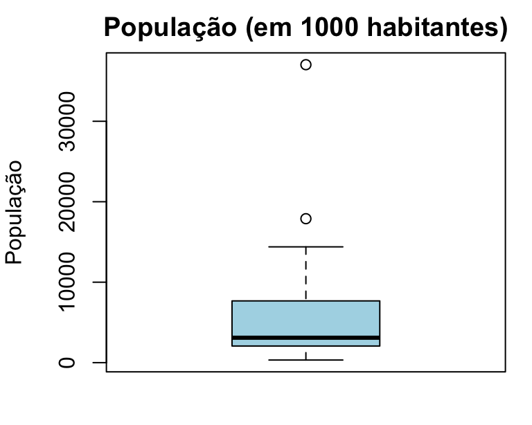

## Exemplo: Quantidade de sódio (mg) em 20 cereais matinais

0, 70, 125, 125, \(\underbrace{140, 150}_{Q_1=145}\), 170, 170, 180, **200**

**200**, 210, 210, 220, \(\underbrace{220, 230}_{Q_3=225}\), 250, 260, 290, 290

\(IQ=Q_3-Q_1=225-145=80\)

\(Q_1-1.5\times IQ=145-1.5\times 80=25\)

## Exemplo: Sódio em cereais matinais

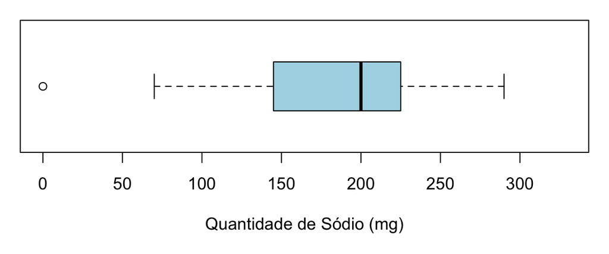

Outlier: observação menor do que 25 ou maior do que 345.

As linhas pontilhadas denotam o mínimo/máximo dos dados que estão na região entre \(Q_1-1.5\times IQ\) e \(Q_3+1.5\times IQ\).

A observação máxima dos dados, 290, está no intervalo, então a linha do lado direito vai até 290.

A observação mínima dos dados, 0, está fora do intervalo (outlier=0).

## Exemplo: Sódio em cereais matinais

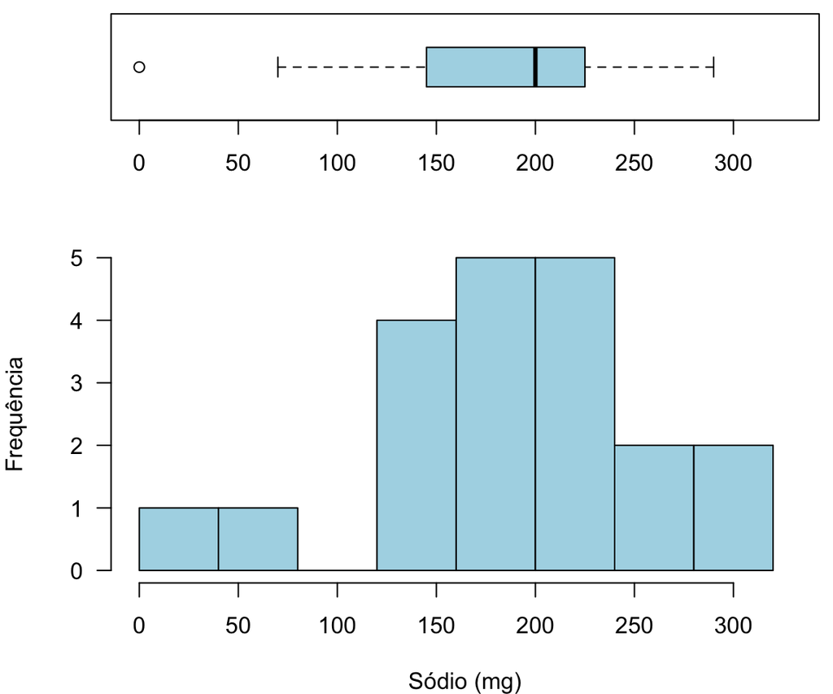

## Boxplot x Histograma

Boxplot não substitui o histograma e vice-versa.

Por exemplo, se a distribuição é bimodal, não observamos isso pelo boxplot.

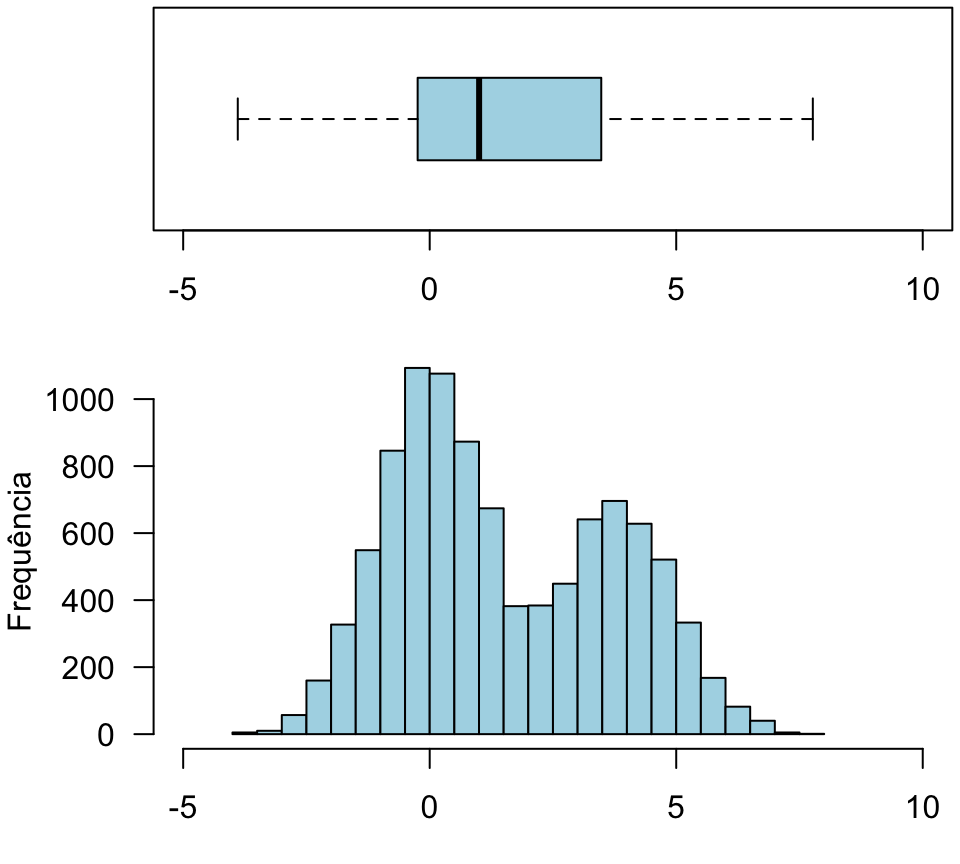

## Exemplo

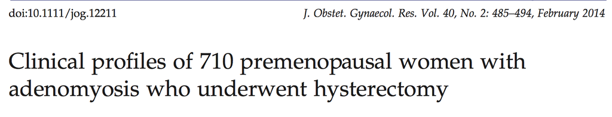

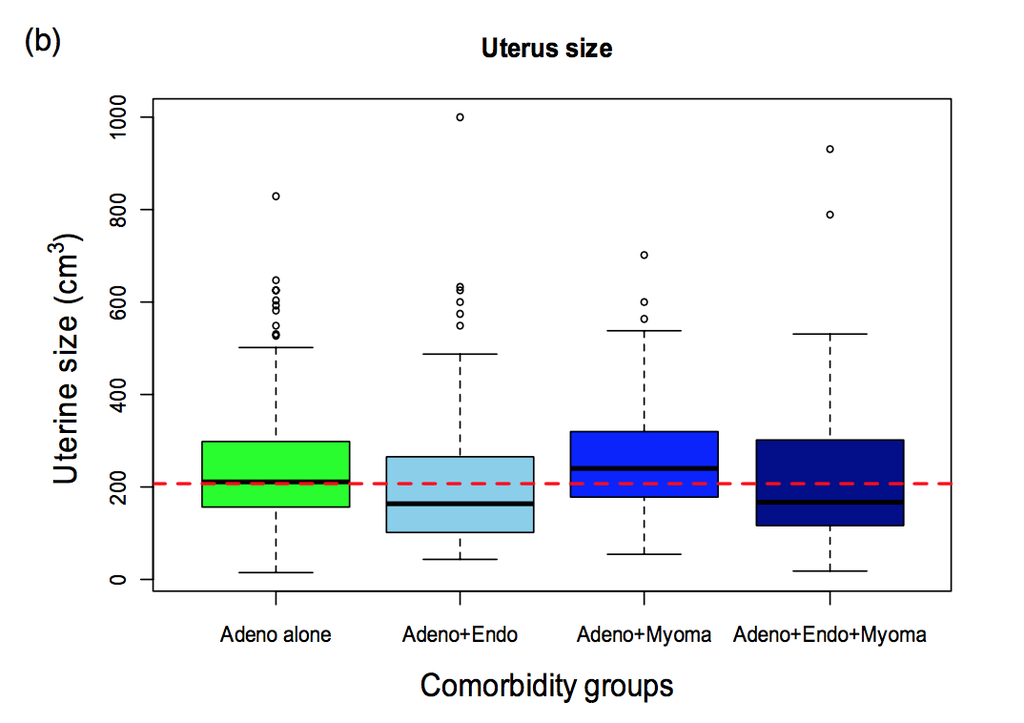

[figure not shown]

Slides produzidos pelos professores:

- Samara Kiihl
- Tatiana Benaglia
- Benilton Carvalho
- Rafael Maia